# EDA-Global Financial Inclusion (Global Findex) Database 2021

Juan José Alvarado

2025-04-14

# Introduction

Discovering and satisfying that curiosity proper of those who like the world of data has never been this easy. Check out this short exploratory data analysis about financial inclusion around the world!

The data was gathered in more than 130 countries, interviewing people over 15 years old. You can get more information -and the raw data- about the study here: [Microdata Library World Bank](https://microdata.worldbank.org/index.php/catalog/4607/related-materials).

# Packages Used and Data Load

I did a little of data pre-processing using Microsoft Excel. Things like changing to “yes” or “no” type of answer instead of “1” or “2” to gain a little more of comprehension, changing fields names, etc. You will find a PDF with the variable names and definitions of the raw data alongside this file if you need to get clarification.

For this project I selected only 19 out of the more than 100 available variables and made a new csv file with this data set named “financial_data.csv”.

The packages used in this project are **readr** to load the csv file in R and **tidyverse** for data manipulation.

```r
library(readr)
library(tidyverse)
```

Next, load the data set with the variables you are interested in to explore and create a data frame.

```r
data <- read_csv("financial_data.csv")
# Take note: if you need to set the working directory
# setwd("path_where_the_csv_file_is_in_your_pc")
```

# Exploring the Data

Get to know the data before manipulating or visualizing anything.

## First Look into the data frame

```r
#Data Structure
str(data)
```

```
## spc_tbl_ [143,887 × 19] (S3: spec_tbl_df/tbl_df/tbl/data.frame)
##  $ economy            : chr [1:143887] "Afghanistan" "Afghanistan" "Afghanistan" "Afghanistan" ...
##  $ economycode        : chr [1:143887] "AFG" "AFG" "AFG" "AFG" ...
##  $ regionwb           : chr [1:143887] "South Asia" "South Asia" "South Asia" "South Asia" ...
##  $ pop_adult          : num [1:143887] 22647496 22647496 22647496 22647496 22647496 ...
##  $ gender             : chr [1:143887] "Male" "Male" "Female" "Male" ...
##  $ age                : num [1:143887] 43 55 15 23 46 30 50 46 19 40 ...
##  $ educ               : chr [1:143887] "Secondary" "Primary" "Primary" "Primary" ...
##  $ emp_in             : chr [1:143887] "Yes" "Yes" "No" "Yes" ...
##  $ urbanicity_fUrbanf : chr [1:143887] "Rural" "Rural" "Rural" "Urban" ...
##  $ account            : chr [1:143887] "Yes" "No" "No" "No" ...
##  $ saved              : chr [1:143887] "No" "No" "No" "No" ...
##  $ borrowed           : chr [1:143887] "Yes" "Yes" "Yes" "No" ...
##  $ receive_wages      : chr [1:143887] "Not received" "Not received" "Not received" "Cash" ...
##  $ receive_pension    : chr [1:143887] "Not received" "Not received" "Not received" "Not received" ...
##  $ receive_agriculture: chr [1:143887] "Not received" "Cash" "Not received" "Cash" ...
##  $ mobileowner        : chr [1:143887] "Yes" "Yes" "No" "Yes" ...
##  $ internetaccess     : chr [1:143887] "No" "No" "No" "No" ...
##  $ anydigpayment      : chr [1:143887] "Yes" "No" "No" "No" ...
##  $ year               : num [1:143887] 2021 2021 2021 2021 2021 ...
##  - attr(*, "spec")=
##   .. cols(
##   ..   economy = col_character(),
##   ..   economycode = col_character(),
##   ..   regionwb = col_character(),
##   ..   pop_adult = col_double(),
##   ..   gender = col_character(),
##   ..   age = col_double(),
##   ..   educ = col_character(),
##   ..   emp_in = col_character(),
##   ..   urbanicity_fUrbanf = col_character(),
##   ..   account = col_character(),
##   ..   saved = col_character(),
##   ..   borrowed = col_character(),
##   ..   receive_wages = col_character(),
##   ..   receive_pension = col_character(),
##   ..   receive_agriculture = col_character(),
##   ..   mobileowner = col_character(),
##   ..   internetaccess = col_character(),
##   ..   anydigpayment = col_character(),
##   ..   year = col_double()
##   .. )
##  - attr(*, "problems")=<externalptr>
```

```r
#Numeric variable statistics resume
summary(data)
```

```
##    economy          economycode          regionwb           pop_adult
##  Length:143887      Length:143887      Length:143887      Min.   :2.952e+05
##  Class :character   Class :character   Class :character   1st Qu.:4.610e+06
##  Mode  :character   Mode  :character   Mode  :character   Median :9.612e+06
##                                                           Mean   :7.412e+07
##                                                           3rd Qu.:3.372e+07
##                                                           Max.   :1.154e+09
##
##     gender               age            educ              emp_in
##  Length:143887      Min.   :15.00   Length:143887      Length:143887
##  Class :character   1st Qu.:27.00   Class :character   Class :character
##  Mode  :character   Median :38.00   Mode  :character   Mode  :character
##                     Mean   :41.06
##                     3rd Qu.:54.00
##                     Max.   :99.00
##                     NA's   :467
##  urbanicity_fUrbanf   account             saved             borrowed
##  Length:143887      Length:143887      Length:143887      Length:143887
##  Class :character   Class :character   Class :character   Class :character
##  Mode  :character   Mode  :character   Mode  :character   Mode  :character
##
##
##
##
##  receive_wages      receive_pension    receive_agriculture mobileowner
##  Length:143887      Length:143887      Length:143887       Length:143887
##  Class :character   Class :character   Class :character    Class :character
##  Mode  :character   Mode  :character   Mode  :character    Mode  :character
##
##
##
##
##  internetaccess     anydigpayment           year
##  Length:143887      Length:143887      Min.   :2021
##  Class :character   Class :character   1st Qu.:2021
##  Mode  :character   Mode  :character   Median :2021
##                                        Mean   :2021
##                                        3rd Qu.:2021
##                                        Max.   :2022
##
```

```r
#Data set dimensions
dim(data)
```

```
## [1] 143887     19
```

- In this project’s case I’m working with a data frame that has 143887 observations and 19 fields.
- Only three fields are of numerical type: pop_adult, age, year.

## Descriptive Analysis and First Visual Look

1. We could check how many observations are by economy (country).

```r
table(data$economy)
```

```
##
##             T\xfcrkiye            Afghanistan                Albania
##                   1000                   1002                   1000
##                Algeria              Argentina                Armenia
##                   1002                   1003                   1000
##              Australia                Austria             Azerbaijan
##                   1000                   1000                   1008
##             Bangladesh                Belgium                  Benin
##                   1000                   1012                   1000
##                Bolivia Bosnia and Herzegovina               Botswana
##                   1000                   1000                   1000
##                 Brazil               Bulgaria           Burkina Faso
##                   1002                   1005                   1000
##               Cambodia               Cameroon                 Canada
##                   1000                   1000                   1007
##                   Chad                  Chile                  China
##                   1000                   1000                   3500
##               Colombia                Comoros       Congo, Dem. Rep.
##                   1000                   1000                   1000
##            Congo, Rep.             Costa Rica                Croatia
##                   1000                   1001                   1001
##                 Cyprus                Czechia                Denmark
##                   1019                   1005                   1002
##     Dominican Republic                Ecuador       Egypt, Arab Rep.
##                   1000                   1000                   1003
##            El Salvador                Estonia               Eswatini
##                   1002                   1001                   1000
##               Ethiopia                Finland                 France
##                   1000                   1000                   1000
##                  Gabon            Gambia, The                Georgia
##                   1020                   1000                   1000
##                Germany                  Ghana                 Greece
##                   1000                   1000                   1003
##              Guatemala                 Guinea               Honduras
##                   1000                   1000                   1000
##   Hong Kong SAR, China                Hungary                Iceland
##                   1003                   1003                    502
##                  India              Indonesia     Iran, Islamic Rep.
##                   3000                   1062                   1005
##                   Iraq                Ireland                 Israel
```

[output cut: 40 more lines]

```
##                   1006                   1000                   1000
##             Tajikistan               Tanzania               Thailand
##                   1000                   1001                   1017
##                   Togo                Tunisia                 Uganda
##                   1000                   1000                   1000
##                Ukraine   United Arab Emirates         United Kingdom
##                   1001                   1000                   1000
##          United States                Uruguay             Uzbekistan
##                   1007                   1000                   1000
##          Venezuela, RB                Vietnam     West Bank and Gaza
##                   1000                   1000                   1000
##            Yemen, Rep.                 Zambia               Zimbabwe
##                   1000                   1000                   1000
##       C\xf4te d'Ivoire
##                   1000
```

We can see that the observations are almost *equally distributed*: 1000 observations per economy.

2. We could also use graphs to gather information about the distribution of different variables. I’ll do it with the fields region, gender, pop_adult, educ and age.

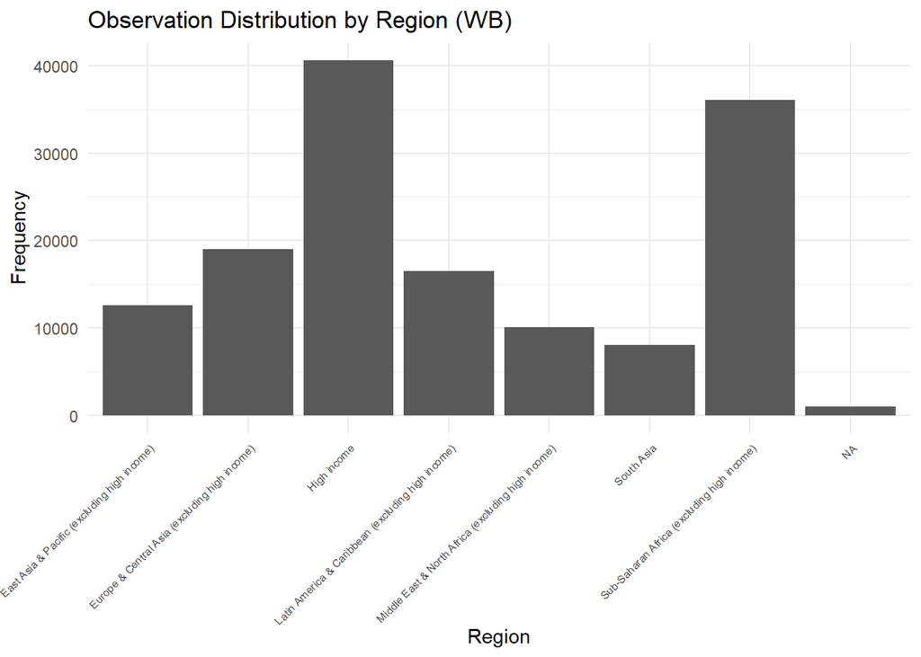

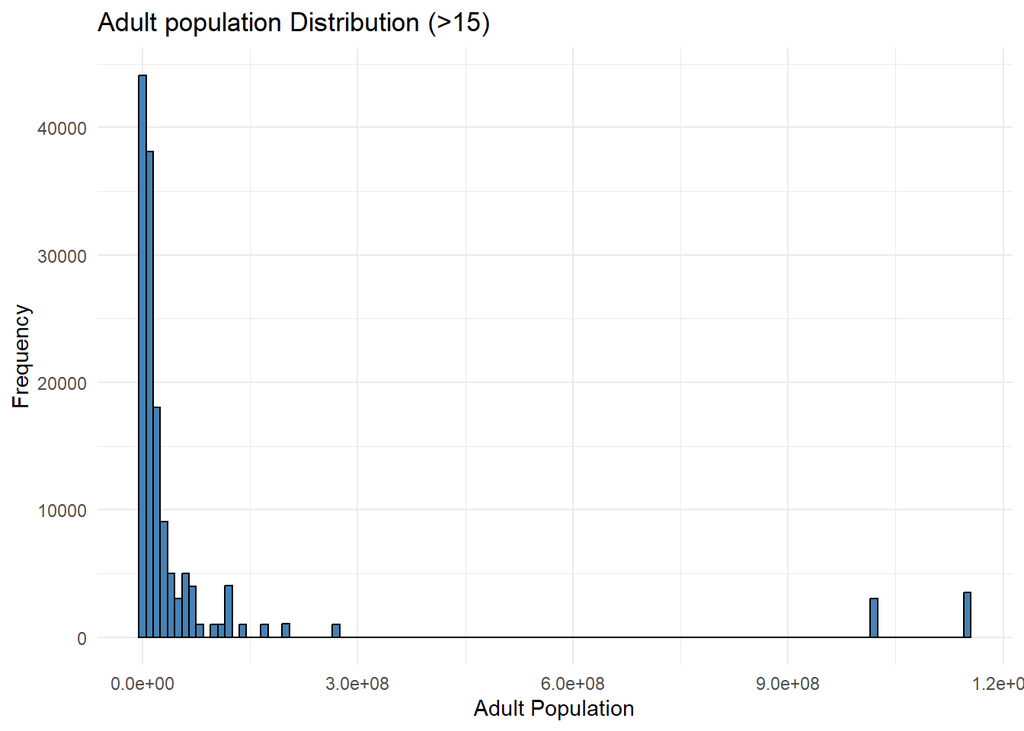

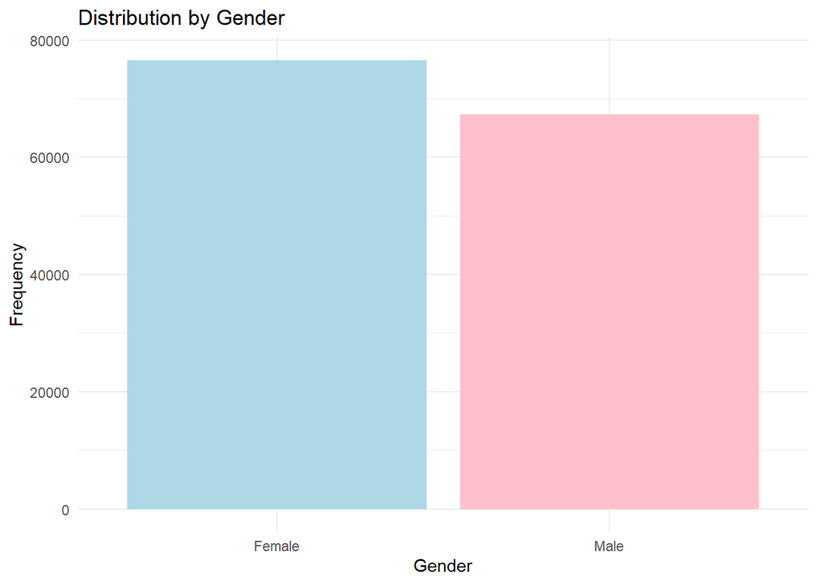

```
##    Min. 1st Qu.  Median    Mean 3rd Qu.    Max.    NA's
##   15.00   27.00   38.00   41.06   54.00   99.00     467
```

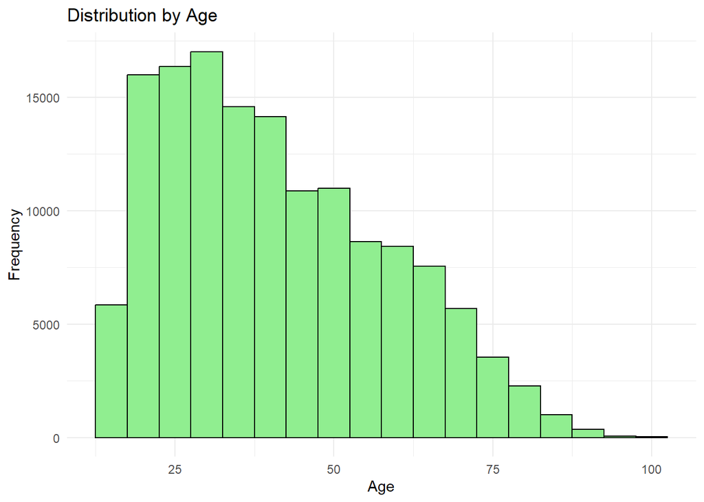

```
##
##         4         5   Primary Secondary  Tertiary
##       395       360     38588     72401     32143
```

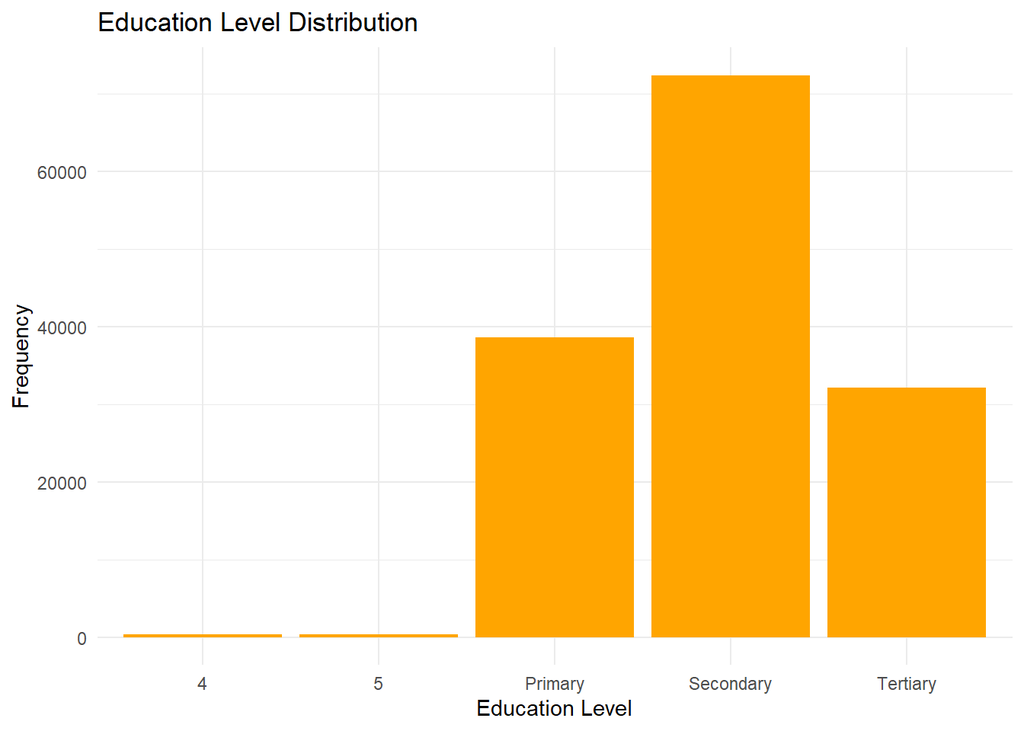

```
##
## Rural Urban
## 31781 43863
```

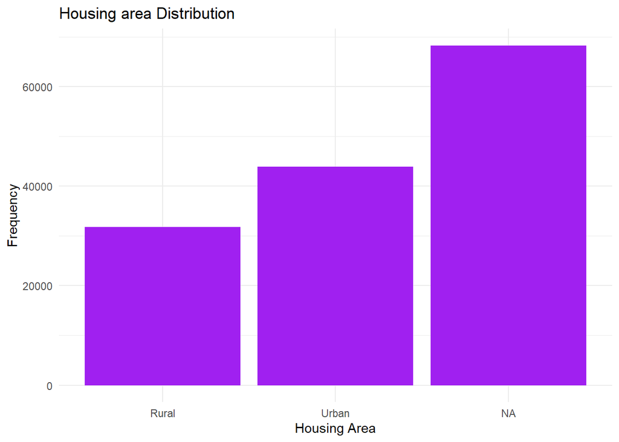

We can get also some intricate information about the demographics of the interviewees:

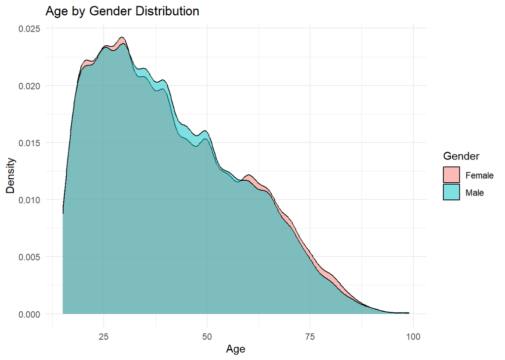

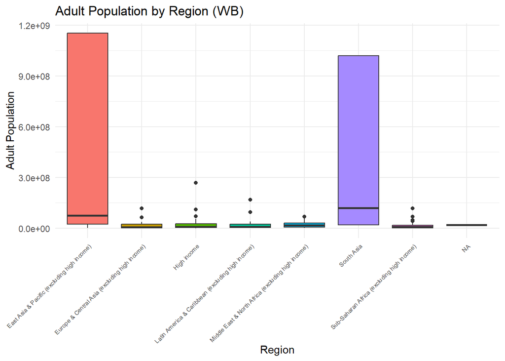

1. The distribution of ages by gender is almost identical.
2. There are considerable differences between the population interviewed for each region. Also there are some regions with economies with significantly larger population from the mean.

# Frequency Analysis Visualization

## Proportions

Now is time to get our hands on the financial inclusion information with categorical variables.

This will give us a general idea of labor force participation, financial inclusion, savings, debt, digital payment use, mobile phone ownership, and internet access in the sample.

It will be easier if you can define a function to create the proportion graphs to visualize the categorical variables.

Here you can check the one I used:

```r
proportion_plot <- function(variable, title){
  prop_table <- prop.table(table(variable))
  df_prop <- data.frame(Result = names(prop_table),
                        Proportion = as.numeric(prop_table))

  ggplot(df_prop, aes(x = Result, y = Proportion, fill = Result)) +
    geom_bar(stat = "identity") +
    geom_text(aes(label = scales::percent(Proportion)), vjust = -0.3) +
    labs(title = title, x = NULL, y = "Proportion") +
    scale_y_continuous(labels = scales::percent) +
    theme_minimal() +
    theme(legend.position = "none")
}
```

Now you only need to call the function, enter the variable you want to visualize and give the graph a title:

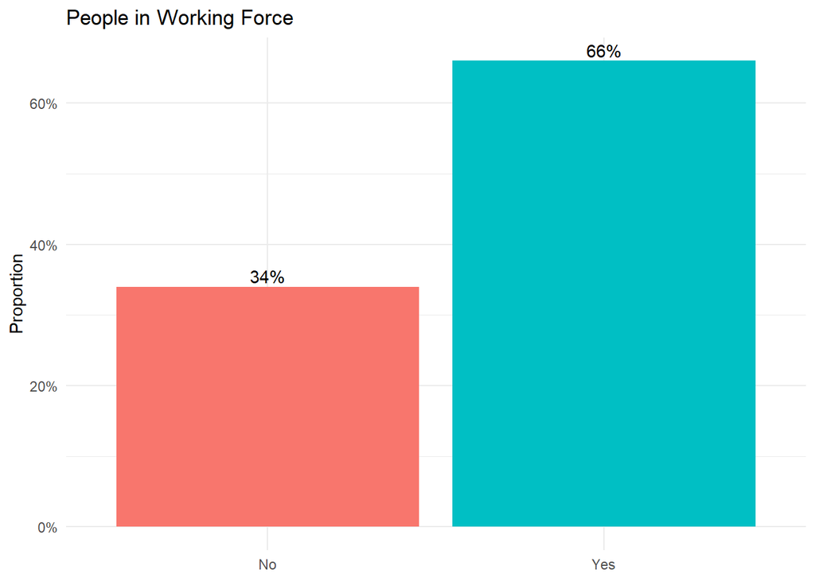

```r
proportion_plot(data$emp_in, "People in Working Force")
```

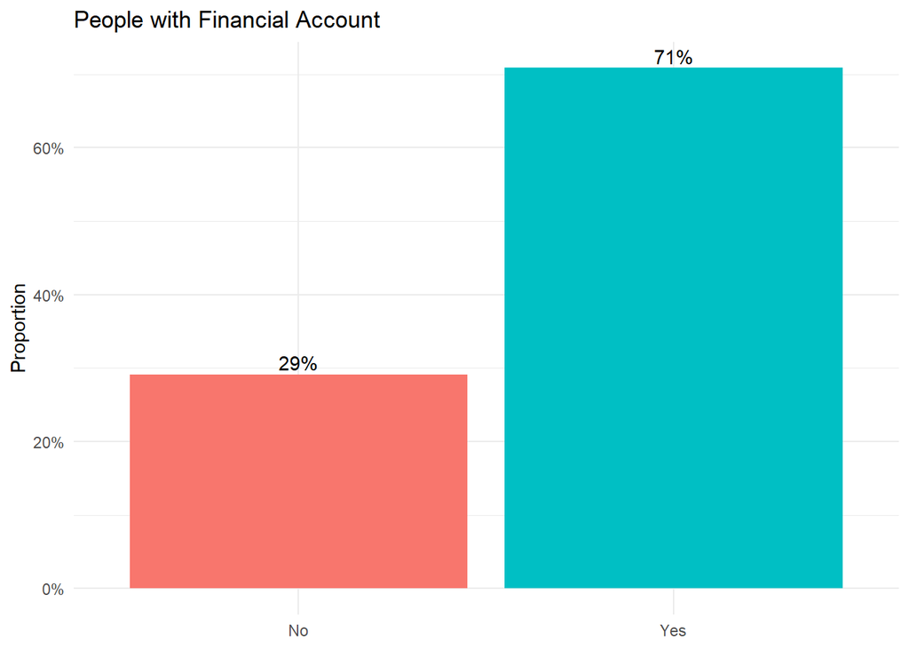

```r
proportion_plot(data$account, "People with Financial Account")
```

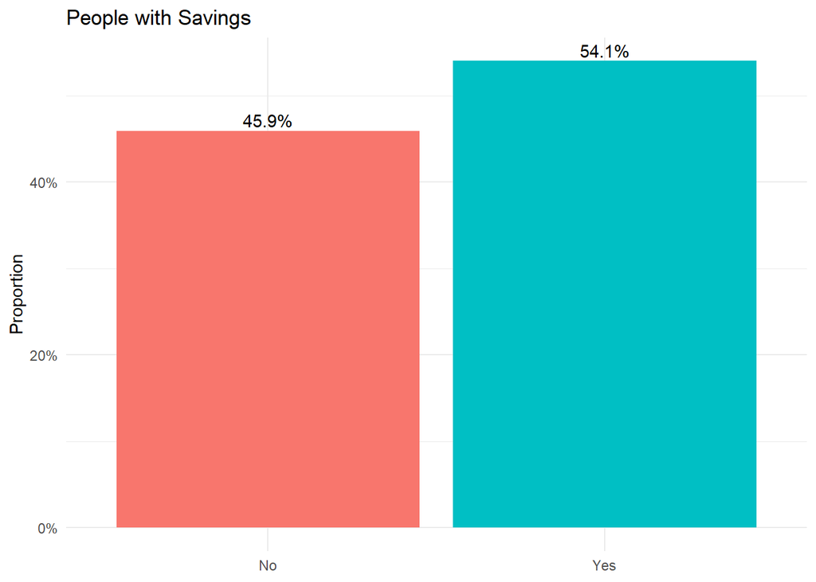

```r
proportion_plot(data$saved, "People with Savings")
```

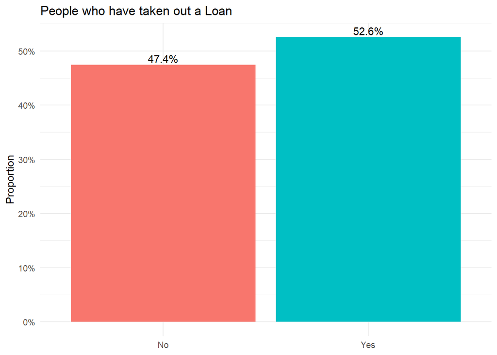

```r
proportion_plot(data$borrowed, "People who have taken out a Loan")
```

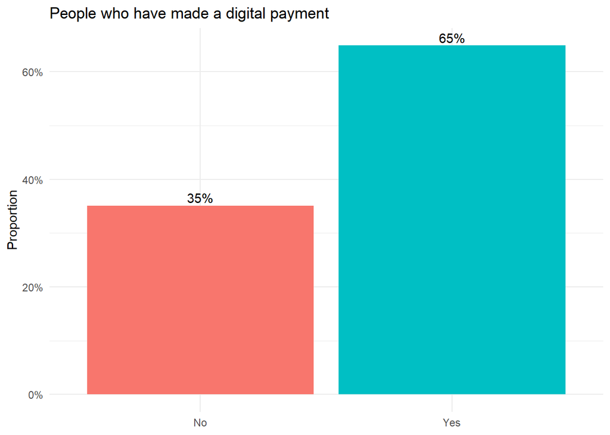

```r
proportion_plot(data$anydigpayment, "People who have made a digital payment")
```

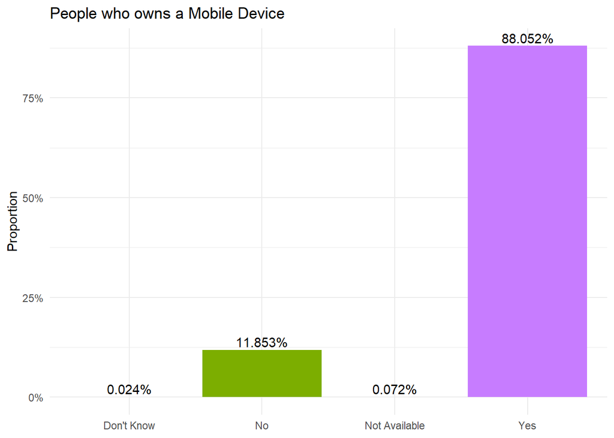

```r
proportion_plot(data$mobileowner, "People who owns a Mobile Device")
```

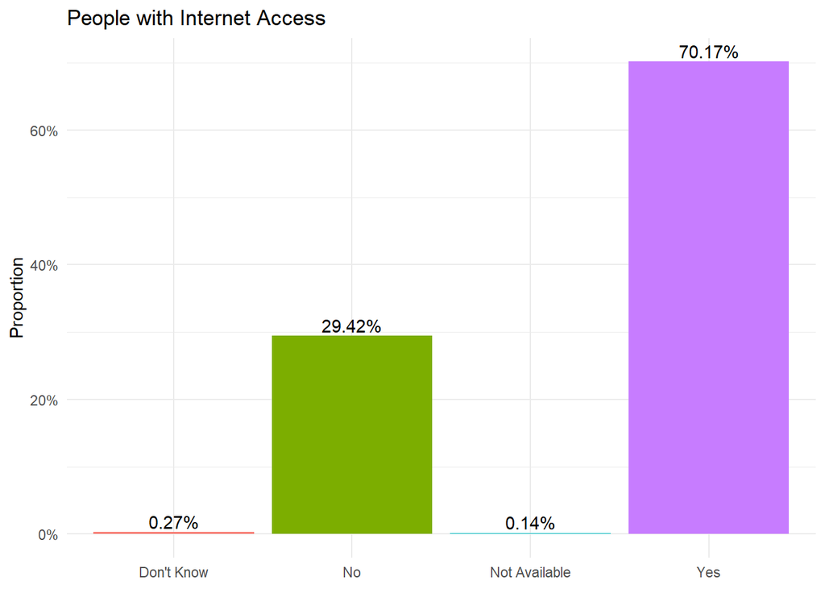

```r
proportion_plot(data$internetaccess, "People with Internet Access")
```

- We got that **most** of the people are in the working force, **have** a financial account, **half of them** have savings, **half of them** have taken out a loan.
- **65% of interviewees** have made a digital payment, the **majority** owns a mobile device and have internet access.

## Categorical Variables vs Demographics

Discover how these categorical variables are distributed among the different categories of our demographic variables has immense value. I used basic bar graphs to showcase the results.

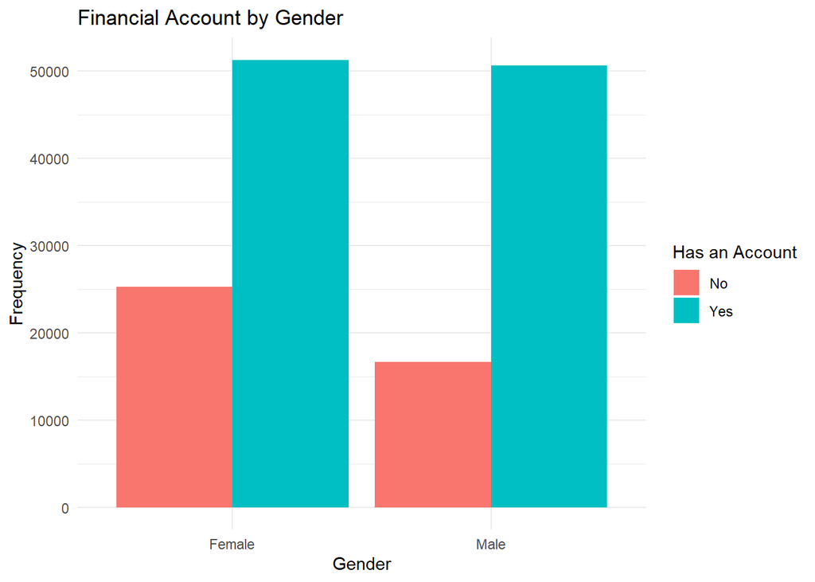

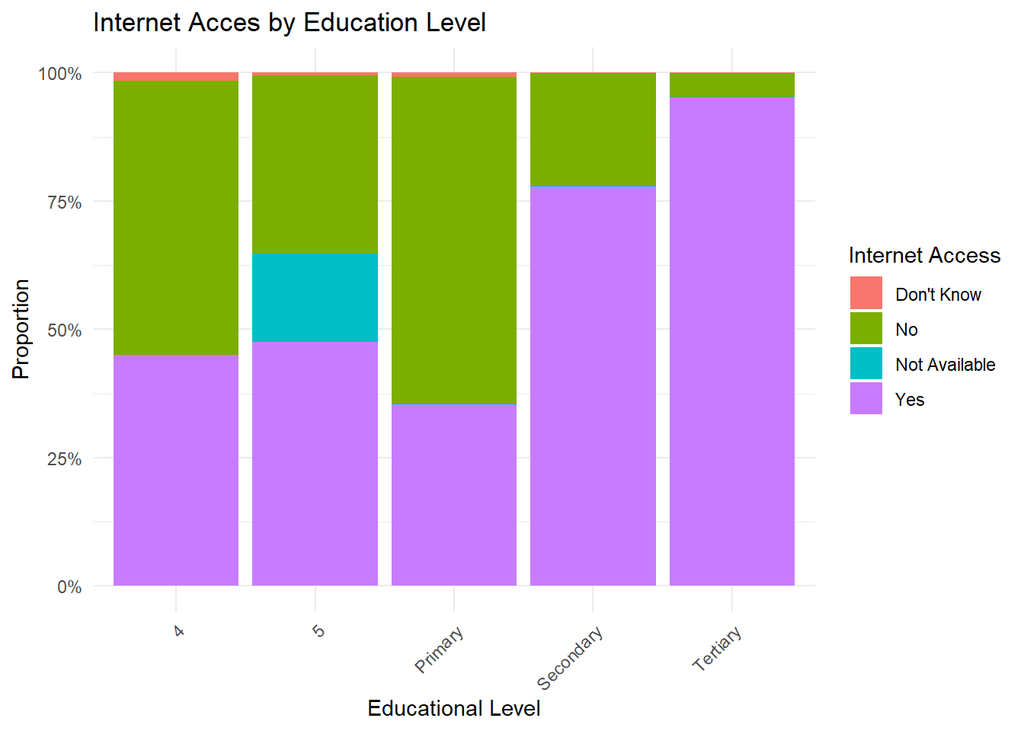

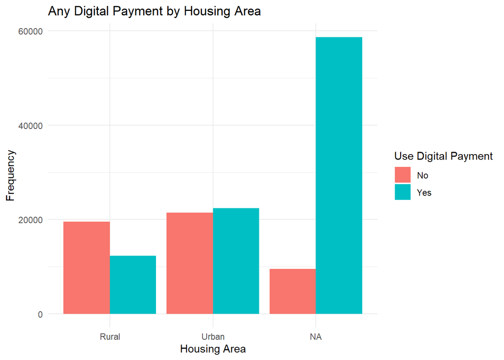

### Distribution Analysis by Category

We can also show the distribution of categorical variables with multiple levels (not only with binary answers) and compare them.

In this section we’ll explore the distribution of these variables first, and then the comparison between them and some demographic variables as we did previously.

As always creating a function to do the proportion bar graphs will make it quick and easier:

```r
distribution_plot <- function(variable, title){
  df_freq <- as.data.frame(table(variable))
  colnames(df_freq) <- c("Category", "Frequency")

  ggplot(df_freq, aes(x = Category, y = Frequency, fill = Category)) +
    geom_bar(stat = "identity") +
    geom_text(aes(label = Frequency), vjust = -0.3) +
    labs(title = title, x = NULL, y = "Frequency") +
    theme_minimal() +
    theme(legend.position = "right",
          axis.text.x = element_text(angle = 45, hjust = 1))
}
```

Now we will explore the variables with multiple categorical levels:

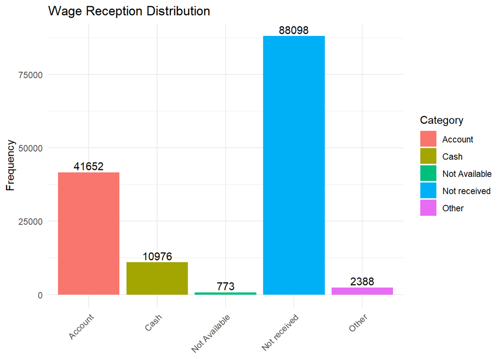

```r
distribution_plot(data$receive_wages, "Wage Reception Distribution")
```

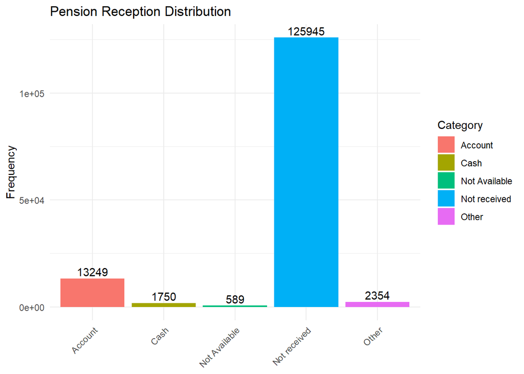

```r
distribution_plot(data$receive_pension, "Pension Reception Distribution")
```

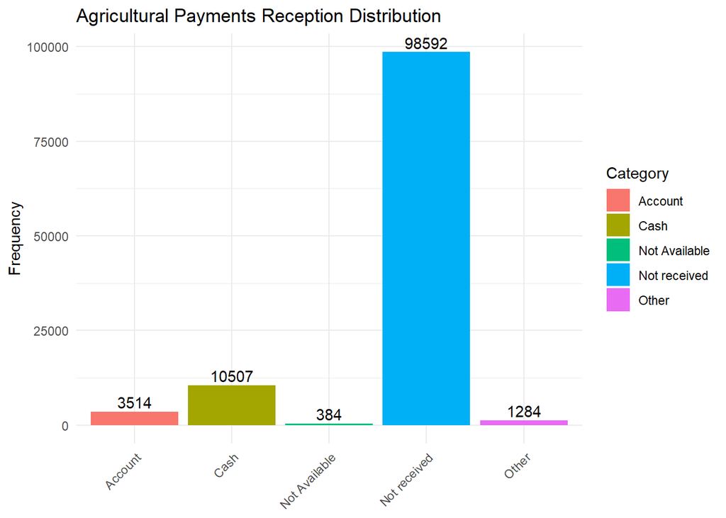

```r
distribution_plot(data$receive_agriculture, "Agricultural Payments Reception Distribution")
```

- It is interesting to see that most of the interviewees have never received a salary; maybe they have an income but not in the form of a salary.
- Also most of them never received a pension. We have to consider that most of the interviewees are under 40 years old.
- Finally most of the people have never received a payment by selling or offering agricultural goods or services.

To conclude this project I want to know how some of the demographic variables relate to these last categorical data.

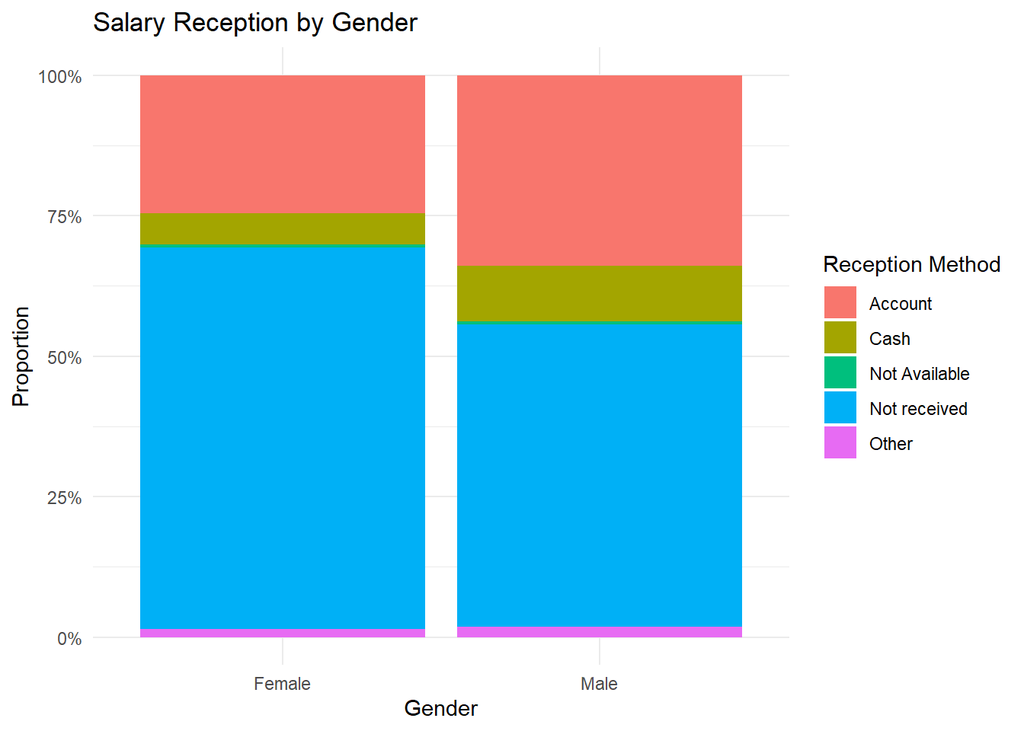

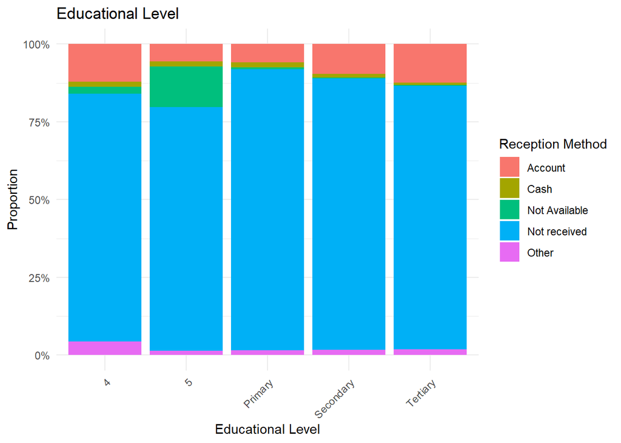

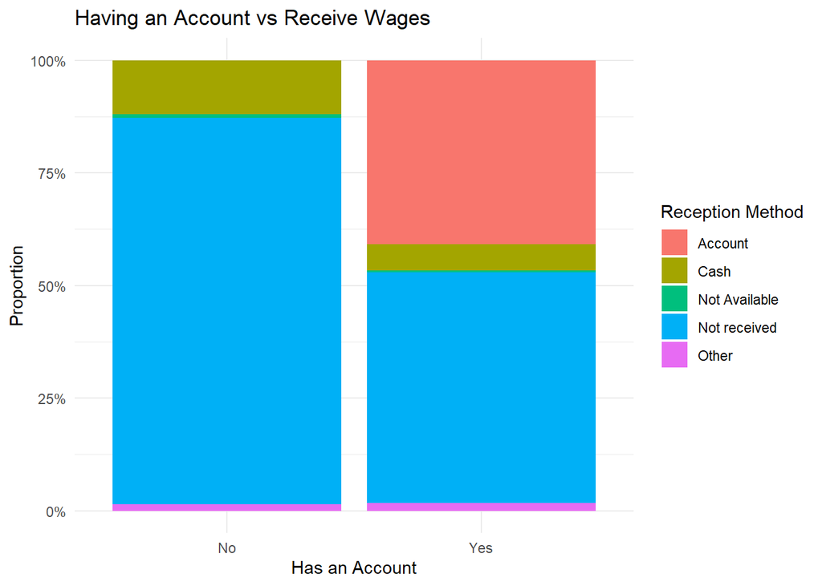

# Overview

It is impressive how easy and quick you can extract valuable information from any kind of data just by understanding the structure it has and what it measures or describes.

Visualizing the data is always better when you want to understand what is happening, it allows you to catch trending and patterns.

I only did a few demonstrations of what kind of information you can gather but you can always explore further an get the most intricate data results as you want.

How does mobile phone ownership vary by region? Is savings related to educational level? Could it be relevant to analyze the proportion of “not available” in different groups? Just to name a few.

The important thing is you only need curiosity and data to do great things!